# Aplicaciones de los momentos de una distribución

La entropia diferencial

# Introducción

Los momentos de una distribución de probabilidad, la cual recordemos puede ser de dos tipos: con respecto al origen y centrales, se representan como:
$$\mathbb{E}(X^n) = \int_{-\infty}^{\infty}{x^n f(x)dx}\\
\mathbb{E}([X-\mu]^n)= \int_{-\infty}^{\infty}{(x-\mu)^n f(x)dx}$$
De igual forma, los momentos se pueden calcular para una función de una variable aleatoria y pueden tomar la siguiente forma:
$$\mathbb{E}(g(X))= \int_{-\infty}^{\infty}{g(x)f(x)dx},$$
donde $f(x)$ es la densidad de probabilidad y $g(x)$ es la la función sobre la variable aleatoria $X$. Una función de importancia práctica es la llamada entropía diferencial, la cual no es más que el momento aplicado a la función $g(x)=\log(f(x))$. Es decir, la entropía diferencial halla el logaritmo a la función de densidad.La entropía diferencial puede aplicarse a variables aleatorias continuas o discretas, ahora, sólo nos concentraremos en el cálculo de la entropía diferencia $h(X)$ de algunas densidades continuas conocidas. La entropía diferencial de una variable aleatoria $X$ con función de densidad $f(x)$ está entonces dada por la siguiente ecuación:
$$h(X) = -\int_{-\infty}^{+\infty}{f(x) \log(f(x)) \, dx}$$

Y por lo tanto si queremos hallar la entropía diferencial para la variable aleatoria uniforme $\mathcal{U}(a,b)$ que está definida como:

$$\mathcal{U}(a,b) = \begin{cases}
\frac{1}{b-a} & a < x < b\\
0 & \mbox{en otro caso}
\end{cases}$$

entonces, el cálculo de su entropía diferencial debe ser efectuado de la siguiente forma; $h(\mathcal{U}(a,b)) = - \int_a^b{\frac{1}{b-a}\log(\frac{1}{b-a}), \, dx}$ y por lo tando, desarrollando esta ecuación, su entropía diferencial está dada por:

$$\begin{align}
h(X) = & -\int_{a}^b{\left(\frac{1}{b-a}\right) \log(\frac{1}{b-a})
\, dx}\\
= & -\left(\frac{1}{b-a}\right) \log(\frac{1}{b-a}) \times
\int_a^b{dx}\\
= & - \left(\frac{1}{b-a}\right) \log(\frac{1}{b-a})\times (b-a)\\
= & - \log(\frac{1}{b-a}) = \log(b-a)
\end{align}$$

Por lo tanto $h(\mathcal{U}(a,b)) = \log(b-a)$. A continuación, como actividad se hallará la entropía diferencial para diferentes variables aleatorias continuas conocidas.

## Ejercicios.

Una vez visto la forma de calcular la entropía para densidades continuas, el turno será para calcular la entropía diferencial de las siguientes densidades:

1. $$f(x) = \begin{cases} \lambda
   \mbox{e}^{-\lambda x} & x \ge 0\\
   0 & \mbox{en otro caso}\end{cases}$$

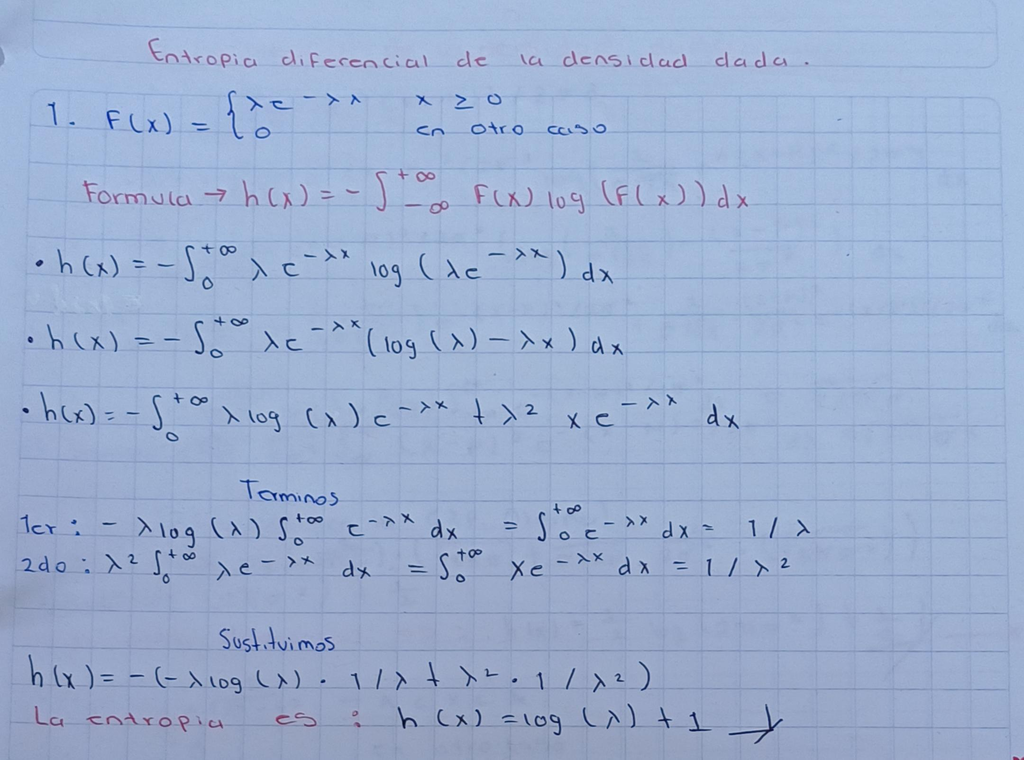

Ejercicio 1 de entropia

2. $$f(x) = \begin{cases}\frac{1}{2}\lambda
   \mbox{e}^{-\lambda |x|} & -\infty < x < \infty\\
   \end{cases}$$

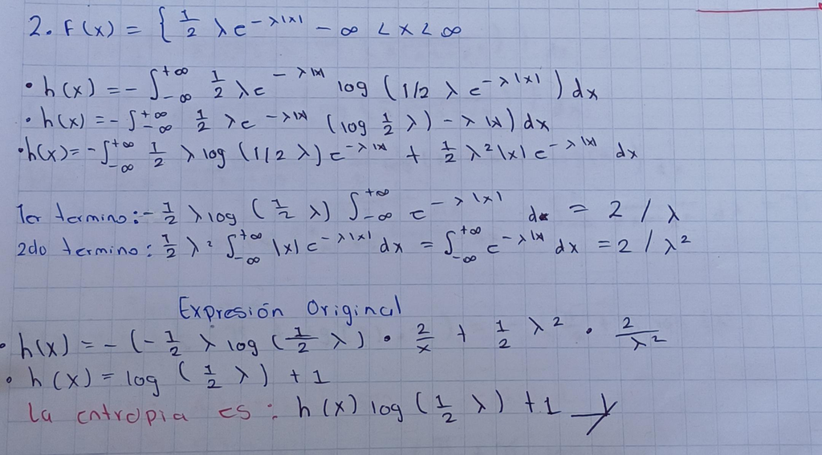

Ejercicio 2 de entropia

3. $$f(x) = \frac{1}{\sigma \sqrt{2
   \pi}}\mbox{e}^{-(x-\mu)^2/2\sigma^2}, -\infty < x < \infty, \,
   \sigma >0$$

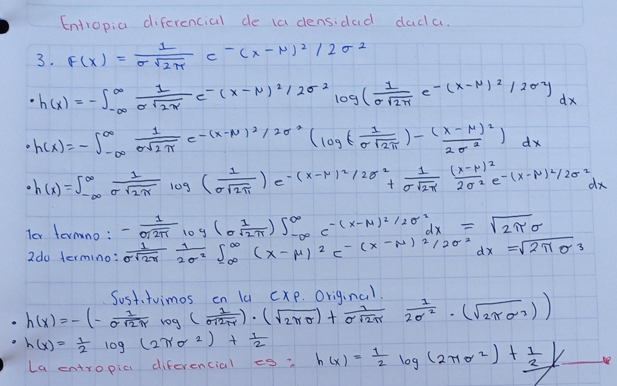

Ejercicio 3 De Entropia

4. $$f(x) =
   \begin{cases}\frac{1}{A\sqrt{A^2-x^2}} & -A < x < A\\
   0 & \mbox{en otro caso}\end{cases}, \; \; A>0$$

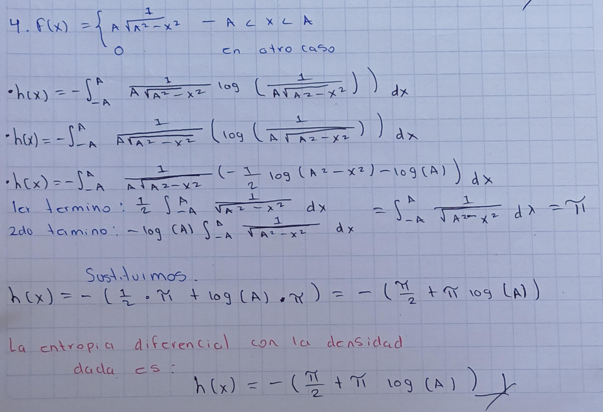

Ejercicio 4 De Entropia

Nota: pueden resolver la actividad en su cuaderno y posteriormente insertar en el HTML la imagen de sus resultados.

Atte. Dr.Julio César Ramírez Pacheco